# 5 - Manipulació de dades

Eudald Correig

11/6/2019

# Introducció

En aquesta classe veurem com manipular dataframes per tenir-los exactament com els necessitem per fer els anàlisis i els gràfics. En concret, aprendrem a separar i ajuntar dataframes, així com de posar-los en el que s’anomena format llarg i format ample.

## Separar dataframes

Sovint necessitarem només troços de cada base de dades per fer cada anàlisi; en aquests casos pot ser convenient extreure només una part del dataframe.

Una forma simple és fer una subselecció com les que ja hem vist. Per exemple, en el dataset indian_liver_patient:

```r
df = read.csv('input/indian_liver_patient.csv')
df_reduit = df[, -c(10,11)]
```

I, si volem triar observacions segons algun criteri:

```r
df_reduit = df[df$Age>65, -c(10,11)]
```

```r
df_reduit = subset(df, select = 1:9)
```

I, si volem triar observacions segons algun criteri:

```r
df_reduit = subset(df, subset = df$Age>65, select = 1:9)
```

## cbind.data.frame i rbind.data.frame

Aquestes són dues funcions simples que utilitzarem per ajuntar dataframes o vectors de la mateixa llargada i que vulguem en el mateix ordre.

Per exemple, imagineu que volem fer un vector amb noms de variables, p-valors, p-valors ajustats i odd ratios per tal de poder-lo ensenyar. Ho faríem de la següent manera (amb totes les dades simulades):

```r
noms = paste0(rep("Var", 8), seq(1, 8, by=1))
pvals = rpois(8, 4)/100
pvals_adj = p.adjust(pvals, method = "BH")
odd_ratio = rnorm(8, 1.1, sd = .1)

tot = cbind.data.frame(noms, pvals, pvals_adj, odd_ratio)
```

```r
require(knitr)
kable(tot)
```

| noms | pvals | pvals_adj | odd_ratio |
| --- | --- | --- | --- |
| Var1 | 0.03 | 0.07 | 1.132951 |
| Var2 | 0.03 | 0.07 | 1.017953 |
| Var3 | 0.04 | 0.07 | 1.148743 |
| Var4 | 0.07 | 0.07 | 1.173833 |
| Var5 | 0.02 | 0.07 | 1.157578 |
| Var6 | 0.07 | 0.07 | 1.069461 |
| Var7 | 0.07 | 0.07 | 1.251178 |
| Var8 | 0.05 | 0.07 | 1.138984 |

I operarem de forma similar amb rbind.dataframe (per exemple si volem ajuntar dades antigues amb noves dades amb exactament el mateix format).

Per fer-ho utilitzarem la funció merge. Ho fem amb els següents tres fitxers, que ens passen de forma separada i volem ajuntar per analitzar:

```r
df1 = read.csv('input/per_ajuntar_1.csv')
df2 = read.csv('input/per_ajuntar_2.csv')
df3 = read.csv('input/per_ajuntar_3.csv')
head(df1)
```

```
##   ID N_BIOBANC  Data.banc
## 1  1         1  2/16/2004
## 2  3        18  6/17/2004
## 3  5        16   6/8/2004
## 4  5        33  9/18/2013
## 5  6        39 11/25/2004
## 6  6       239 12/10/2014
```

```r
head(df2)
```

```
##   ID SEXE DATA.entrada EDAT PES TALLA
## 1  1    1     5/6/1999   33 105   180
## 2  3    1    4/25/2000   35  90   175
## 3  4    1     2/3/2000   36  65   178
## 4  5    1     2/8/2000   43  94   182
## 5  6    1    9/17/1999   46  82   178
## 6  7    1    12/1/1999   45  95   168
```

```r
head(df3)
```

```
##   ID Registre biobanc EMP_count EMP_Gated
## 1  3        1      18       100      4.19
## 2  5        1      16       850      6.18
## 3  5        2      33        63      3.31
## 4  6        1      39       147      1.80
## 5  9        1      54       645      4.17
## 6 11        1     113       217      2.73
```

Fixem-nos que hi ha dos tipus d’identificadors, l’ID, que és únic de cada pacient, i després N_BIOBANC, que és únic per cada observació. Es pot donar, però, que un mateix pacient tingui dos biobancs, i haurem de mirar què fer amb això.

Explorem abans que res la funció merge:

## Funció merge

```r
merge(x, y, by = intersect(names(x), names(y)),
      by.x = by, by.y = by, all = FALSE, all.x = all, all.y = all,
      sort = TRUE, suffixes = c(".x",".y"), no.dups = TRUE,
      incomparables = NULL, ...)
```

Anem per parts:

**x, y**: són els dataframes a ajuntar.

**by, by.x, by.y**: són les claus amb les quals ajuntar-les, és a dir, els noms de les columnes que sabem que tenen la mateixa informació i que ens permeten associar els dos fitxers. Per exemple, en el nostre cas, serien ID i N_BIOBANC. A partir d’aquí tenim dues opcions, si el nom és el mateix en els dos fitxers, podem no posar res i ell per defecte ja els ajuntarà correctement, o podem explicitar-ho afegint *by = “ID”*, per exemple. En el cas de que les dues variables es diguin diferent, haurem d’explicitar-ho utilitzant el *by.x* i el *by.y*, per exemple posant *by.x = “ID”, by.y = “Altre_ID”*.

**all, all.x, all.y**: aquests paràmetres controlen el tipus de merge que farem. *all* vol dir que agafarem totes les entrades, encara que no tinguin correspondència entre fitxers. En els casos que no hi hagi correspondència, posarem missings. Això és el que s’anomena un “outer join”. *all.x* i *all.y* imposen que importem totes les observacions dels fitxers x i y respectivament encara que no tinguin correspondència. S’anomenen “left join” i “right join”. Per defecte, si no posem res, merge fa un “natural (o inner) join”, és a dir, només manté les observacions que es troben en els dos fitxers (i que normalment és el que ens interessa).

En el següent gràfic podem visualitzar aquestes idees:

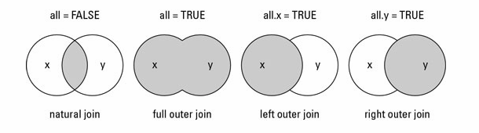

Ho fem a la pràctica:

## Exemple

Ajuntem df1 i df2:

```r
df12 = merge(df1, df2)
head(df12)
```

```
##   ID N_BIOBANC  Data.banc SEXE DATA.entrada EDAT PES TALLA
## 1  1         1  2/16/2004    1     5/6/1999   33 105   180
## 2  3        18  6/17/2004    1    4/25/2000   35  90   175
## 3  5        16   6/8/2004    1     2/8/2000   43  94   182
## 4  5        33  9/18/2013    1     2/8/2000   43  94   182
## 5  6        39 11/25/2004    1    9/17/1999   46  82   178
## 6  6       239 12/10/2014    1    9/17/1999   46  82   178
```

Ajuntem df12 i df3:

```r
df = merge(df12, df3)  # Això no és correcte, alerta!

df = merge(df12, df3, by.x = c("ID", "N_BIOBANC"), by.y = c("ID", "biobanc"))  # Això sí
head(df)
```

```
##   ID N_BIOBANC  Data.banc SEXE DATA.entrada EDAT PES TALLA Registre
## 1 11       113  10/5/2010    1   12/15/1999   46  85   172        1
## 2 15         8  5/11/2004    0    1/12/1999   50  70   151        1
## 3 16        11  5/25/2004    1   11/18/1998   50  64   159        1
## 4 17        36 10/14/2004    1    3/28/2000   55  74   173        1
## 5  3        18  6/17/2004    1    4/25/2000   35  90   175        1
## 6  5        16   6/8/2004    1     2/8/2000   43  94   182        1
##   EMP_count EMP_Gated
## 1       217      2.73
## 2       112      2.50
## 3      2156     16.90
## 4       985      8.29
## 5       100      4.19
## 6       850      6.18
```

# Canvis de format

Ara volem canviar dades que estaven en columnes a una sola columna o al revés. Per exemple, imagineu que tenim un experiment en el qual prenem mesures abans i després de prendre un medicament. Normalment, a l’hora de guardar les dades, creem una columna per cada moment de prendre les dades. Això, però, no ens permet fer regressions o models mixtes en R, així que les haurem de posar en una mateixa columna.

Per fer aquestes operacions utilitzarem el paquet reshape2 i les funcions melt, dcast i reshape, que és una generalització de les dues.

Treballarem amb les següents dades:

```r
require(reshape2)
df = read.csv('input/dades_reshape.csv')
df$edat = round(df$edat)
head(df)
```

```
##     ID grup edat glucosa0 glucosa1 glucosa2 glucosa3 glucosa4
## 1 1001  Pre   65      6.2      6.8      7.5      8.4      9.6
## 2 1003  Pre   48      5.2      5.8      7.2      6.4      6.3
## 3 1004  Pre   32      4.5      5.4      6.3      5.9      5.9
## 4 1005  Pre   37      5.2      5.5      5.4      6.3      4.4
## 5 1006  Pre   47      4.5      6.6      6.2      6.6      6.4
## 6 1009  Pre   44      6.3      7.8     10.5     11.9      8.0
```

Veiem que tenim moltes variables glu; això és perquè estem treballant amb una corba de la glucosa. Per tal de poder fer models amb aquestes dades, necessitem que estiguin en una mateixa columna.

Això ho farem amb la funció melt:

## Melt

```r
melt(data, id.vars, measure.vars,
  variable.name = "variable", ..., na.rm = FALSE, value.name = "value",
  factorsAsStrings = TRUE)
```

Per parts:

**data**: el dataframe que volem canviar. **id.vars**: les variables que s’utilitzen per identificar cada pacient o observació, és a dir, aquelles que són fixes en diferents punts del temps (en el nostre cas, ID, grup i edat). **measure.vars**: aquestes són les variables de mesura, i per tant les que sí que canvien durant el temps. En el nostre cas totes les que comencen per glucosa. **value.name**: li podem donar un nom a la variable que crearà, per exemple en el nostre cas una bona opció podria ser “glucosa”.

Ho fem:

```r
dfm = melt(df, id.vars = c("ID", "grup", "edat"), measure.vars = 4:8, value.name = "glucosa")
head(dfm)
```

```
##     ID grup edat variable glucosa
## 1 1001  Pre   65 glucosa0     6.2
## 2 1003  Pre   48 glucosa0     5.2
## 3 1004  Pre   32 glucosa0     4.5
## 4 1005  Pre   37 glucosa0     5.2
## 5 1006  Pre   47 glucosa0     4.5
## 6 1009  Pre   44 glucosa0     6.3
```

```r
require(lattice)
```

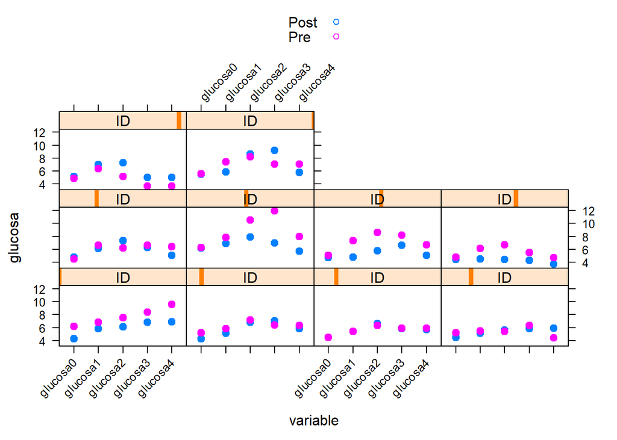

```r
xyplot(glucosa ~ variable | ID,
       data=dfm,
       group = grup,
       auto.key=T,
       scales=list(x=list(rot=45)),
       pch = 20,
       cex = 1.5,
      title = "Glucosa pre i post")
```

```r
model = glm(grup~ variable:glucosa + edat, dfm, family = "binomial")
summary(model)
```

```
##
## Call:
## glm(formula = grup ~ variable:glucosa + edat, family = "binomial",
##     data = dfm)
##
## Deviance Residuals:
##    Min      1Q  Median      3Q     Max
## -1.709  -1.098  -0.183   1.143   1.679
##
## Coefficients:
##                          Estimate Std. Error z value Pr(>|z|)
## (Intercept)              -2.67397    1.24839  -2.142  0.03220 *
## edat                     -0.02307    0.01832  -1.259  0.20788
## variableglucosa0:glucosa  0.74761    0.28694   2.605  0.00918 **
## variableglucosa1:glucosa  0.62539    0.23687   2.640  0.00828 **
## variableglucosa2:glucosa  0.53647    0.20772   2.583  0.00980 **
## variableglucosa3:glucosa  0.55436    0.21795   2.543  0.01098 *
## variableglucosa4:glucosa  0.63760    0.24420   2.611  0.00903 **
## ---
## Signif. codes:  0 '***' 0.001 '**' 0.01 '*' 0.05 '.' 0.1 ' ' 1
##
## (Dispersion parameter for binomial family taken to be 1)
##
##     Null deviance: 138.63  on 99  degrees of freedom
## Residual deviance: 129.53  on 93  degrees of freedom
## AIC: 143.53
##
## Number of Fisher Scoring iterations: 4
```

## dcast

*Per recordar-ho:* melt és el procés de fondre el metall per tal de crear nous objectes (cast).

```r
dcast(data, formula, fun.aggregate = NULL, ..., margins = NULL,
  subset = NULL, fill = NULL, drop = TRUE,
  value.var = guess_value(data))
```

Per parts:

**data**: el dataframe que volem canviar. **formula**: serà la fórmula que ens permetrà especificar quines variables depenen de quines i per tant com s’han de canviar. Bàsicament hem de posar totes les variables que ens interessin en funció d’aquella que vulguem separar (en el nostre cas el grup).

Refem doncs el canvi que havíem fet amb melt:

```r
dfc = dcast(dfm, ID + grup + edat ~ variable, value.var = "glucosa")
head(dfc)
```

```
##     ID grup edat glucosa0 glucosa1 glucosa2 glucosa3 glucosa4
## 1 1001 Post   65      4.3      5.8      6.1      6.8      6.9
## 2 1001  Pre   65      6.2      6.8      7.5      8.4      9.6
## 3 1003 Post   48      4.3      5.1      6.8      7.0      5.8
## 4 1003  Pre   48      5.2      5.8      7.2      6.4      6.3
## 5 1004 Post   32      4.5      5.4      6.6      5.8      5.7
## 6 1004  Pre   32      4.5      5.4      6.3      5.9      5.9
```

Ara imaginem que volem posar el pre i el post en columnes diferents, això ho fem amb la funció dcast (que és simplement la funció cast per dataframes):

```r
dfc2 = dcast(dfm, ID + edat + variable ~ grup, value.var = "glucosa")
head(dfc2)
```

```
##     ID edat variable Post Pre
## 1 1001   65 glucosa0  4.3 6.2
## 2 1001   65 glucosa1  5.8 6.8
## 3 1001   65 glucosa2  6.1 7.5
## 4 1001   65 glucosa3  6.8 8.4
## 5 1001   65 glucosa4  6.9 9.6
## 6 1003   48 glucosa0  4.3 5.2
```

Ara per exemple podem calcular fàcilment la diferència i dibuixar-la:

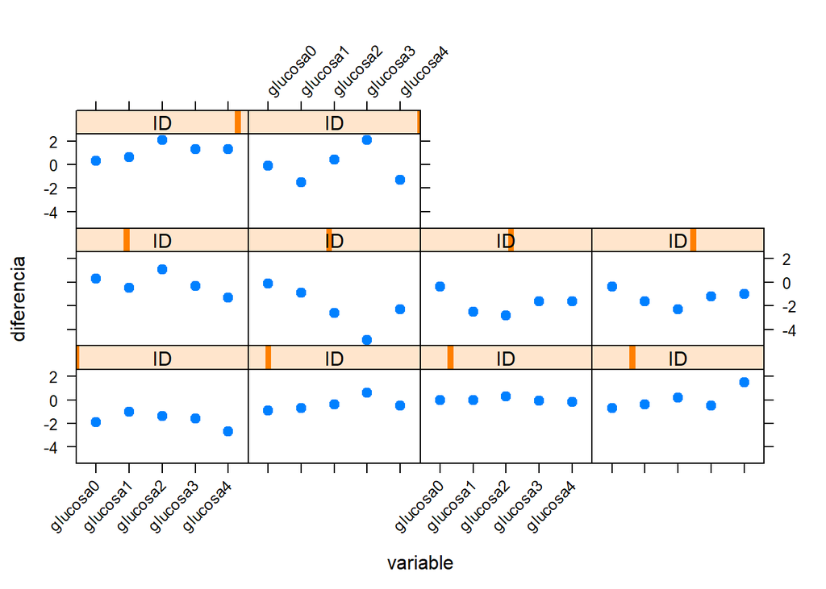

```r
dfc2$diferencia = dfc2$Post - dfc2$Pre
xyplot(diferencia ~ variable | ID,
       data=dfc2,
       auto.key=T,
       scales=list(x=list(rot=45)),
       pch = 20,
       cex = 1.5,
      title = "Diferència per pacient")
```

Per acabar, tenim la funció reshape, que inclou les dues:

## reshape

```r
reshape(data, varying = NULL, v.names = NULL, timevar = "time",
        idvar = "id", ids = 1:NROW(data),
        times = seq_along(varying[[1]]),
        drop = NULL, direction, new.row.names = NULL,
        sep = ".",
        split = if (sep == "") {
            list(regexp = "[A-Za-z][0-9]", include = TRUE)
        } else {
            list(regexp = sep, include = FALSE, fixed = TRUE)}
        )
```

Anem per parts:

**data**: és el dataframe que volem reformatejar.

Fem doncs el mateix que hem fet abans amb el melt i el cast però utilitzant només el reshape:

```r
dfm = reshape(df, varying = 4:8, times = names(df)[4:8], v.names = "glucosa", direction = "long")
dfm$id = NULL
head(dfm)
```

```
##              ID grup edat     time glucosa
## 1.glucosa0 1001  Pre   65 glucosa0     6.2
## 2.glucosa0 1003  Pre   48 glucosa0     5.2
## 3.glucosa0 1004  Pre   32 glucosa0     4.5
## 4.glucosa0 1005  Pre   37 glucosa0     5.2
## 5.glucosa0 1006  Pre   47 glucosa0     4.5
## 6.glucosa0 1009  Pre   44 glucosa0     6.3
```

I si volem tornar enrera:

```r
dfc = reshape(dfm, timevar = "time", idvar = c("ID", "grup", "edat"), direction = "wide")
head(dfc)
```

```
##              ID grup edat glucosa.glucosa0 glucosa.glucosa1
## 1.glucosa0 1001  Pre   65              6.2              6.8
## 2.glucosa0 1003  Pre   48              5.2              5.8
## 3.glucosa0 1004  Pre   32              4.5              5.4
## 4.glucosa0 1005  Pre   37              5.2              5.5
## 5.glucosa0 1006  Pre   47              4.5              6.6
## 6.glucosa0 1009  Pre   44              6.3              7.8
##            glucosa.glucosa2 glucosa.glucosa3 glucosa.glucosa4
## 1.glucosa0              7.5              8.4              9.6
## 2.glucosa0              7.2              6.4              6.3
## 3.glucosa0              6.3              5.9              5.9
## 4.glucosa0              5.4              6.3              4.4
## 5.glucosa0              6.2              6.6              6.4
## 6.glucosa0             10.5             11.9              8.0
```

Veiem que els noms queden una mica estranys, però això es pot arreglar, per exemple fent:

```r
names(dfc)[4:8] = gsub(names(dfc)[4:8], pattern = "glucosa.glucosa", replacement = "glucosa")
head(dfc)
```

```
##              ID grup edat glucosa0 glucosa1 glucosa2 glucosa3 glucosa4
## 1.glucosa0 1001  Pre   65      6.2      6.8      7.5      8.4      9.6
## 2.glucosa0 1003  Pre   48      5.2      5.8      7.2      6.4      6.3
## 3.glucosa0 1004  Pre   32      4.5      5.4      6.3      5.9      5.9
## 4.glucosa0 1005  Pre   37      5.2      5.5      5.4      6.3      4.4
## 5.glucosa0 1006  Pre   47      4.5      6.6      6.2      6.6      6.4
## 6.glucosa0 1009  Pre   44      6.3      7.8     10.5     11.9      8.0
```